# INSTANCE SEGMENTATION

## **5. Inference**

```python
model.eval()
```

[output not shown]

[output cut: 197 more lines]

[output not shown]

```python
# Move to CPU and run inference
with torch.no_grad():
    prediction = model([img_tensor])[0]
```

The output predictions is a list of dictionaries (one dict per image). Each dictionary contains:

- **boxes**

Tensor of shape [N, 4]

Each row is the bounding box coordinates [x_min, y_min, x_max, y_max] for one detected object.

- **labels**

Tensor of shape [N]

The predicted class labels for each detected object (integers corresponding to COCO class indices).

- **scores**

Tensor of shape [N]

The confidence scores (probabilities) for each detected object. Values between 0 and 1.

- **masks**

Tensor of shape [N, 1, H, W]

Binary masks for each detected object. Usually the mask pixels are probabilities between 0 and 1, which you can threshold (e.g., > 0.5) to get a binary mask.

N is the number of objects detected.

```python
masks = prediction['masks']
scores = prediction['scores']
labels = prediction['labels']
boxes = prediction['boxes']
```

```python
prediction['boxes'].shape, prediction['labels'].shape, prediction['scores'].shape, prediction['masks'].shape
```

```
(torch.Size([33, 4]),
 torch.Size([33]),
 torch.Size([33]),
 torch.Size([33, 1, 480, 640]))
```

```python
# COCO classes
COCO_INSTANCE_CATEGORY_NAMES = [
    '__background__', 'person', 'bicycle', 'car', 'motorcycle', 'airplane', 'bus',
    'train', 'truck', 'boat', 'traffic light', 'fire hydrant', 'N/A', 'stop sign',
    'parking meter', 'bench', 'bird', 'cat', 'dog', 'horse', 'sheep', 'cow',
    'elephant', 'bear', 'zebra', 'giraffe', 'N/A', 'backpack', 'umbrella',
    'N/A', 'N/A', 'handbag', 'tie', 'suitcase', 'frisbee', 'skis', 'snowboard',
    'sports ball', 'kite', 'baseball bat', 'baseball glove', 'skateboard',
    'surfboard', 'tennis racket', 'bottle', 'N/A', 'wine glass', 'cup', 'fork',
    'knife', 'spoon', 'bowl', 'banana', 'apple', 'sandwich', 'orange', 'broccoli',
    'carrot', 'hot dog', 'pizza', 'donut', 'cake', 'chair', 'couch',
    'potted plant', 'bed', 'N/A', 'dining table', 'N/A', 'N/A', 'toilet',
    'N/A', 'tv', 'laptop', 'mouse', 'remote', 'keyboard', 'cell phone',
    'microwave', 'oven', 'toaster', 'sink', 'refrigerator', 'N/A', 'book',
    'clock', 'vase', 'scissors', 'teddy bear', 'hair drier', 'toothbrush'
]
```

Print all detections:

```python
labels = prediction['labels']  # Tensor of shape [33]
print(labels)  # This prints the tensor with all label IDs

print("\n")

labels_names = [COCO_INSTANCE_CATEGORY_NAMES[i] for i in labels_list]
print(labels_names)
```

```
tensor([ 1,  1, 62, 44, 72,  3, 44, 44, 47, 44,  1, 46, 72, 44, 47, 79,  1, 47,
         1, 62, 44, 44, 44, 47,  3, 47, 44,  3, 47, 46, 79, 77,  1])


['person', 'person', 'chair', 'bottle', 'tv', 'car', 'bottle', 'bottle', 'cup', 'bottle', 'person', 'wine glass', 'tv', 'bottle', 'cup', 'oven', 'person', 'cup', 'person', 'chair', 'bottle', 'bottle', 'bottle', 'cup', 'car', 'cup', 'bottle', 'car', 'cup', 'wine glass', 'oven', 'cell phone', 'person'…
```

Print only detected objects with scores above the threshold.

```python
scores = prediction['scores'].cpu().numpy()
labels = prediction['labels'].cpu().numpy()

# Set a confidence threshold to filter low-confidence detections (e.g., 0.7)
threshold = 0.7

print("Detected objects with confidence scores:")
for score, label in zip(scores, labels):
    if score >= threshold:
        print(f"{COCO_INSTANCE_CATEGORY_NAMES[label]}: {score:.3f}")
```

```
Detected objects with confidence scores:
person: 1.000
person: 1.000
```

## **6. Visualization**

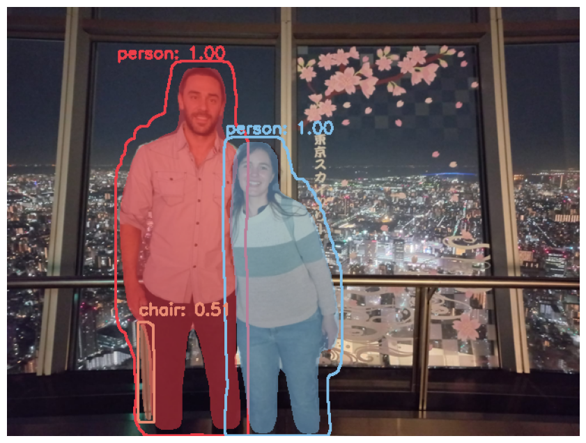

```python
# Convert original image to OpenCV format
img_cv = np.array(img)
img_cv = cv2.cvtColor(img_cv, cv2.COLOR_RGB2BGR)

threshold = 0.5

for i in range(len(masks)):
    if scores[i] >= threshold:
        mask = masks[i, 0].mul(255).byte().cpu().numpy()
        label = COCO_INSTANCE_CATEGORY_NAMES[labels[i]]
        score = scores[i].item()
        box = boxes[i].cpu().numpy().astype(int)

        # Generate a random color
        color = np.random.randint(0, 255, (3,), dtype=np.uint8).tolist()

        # Create colored background
        colored_mask = np.zeros_like(img_cv, dtype=np.uint8)
        for c in range(3):
            colored_mask[:, :, c] = color[c]
        mask_area = mask > 128
        img_cv[mask_area] = cv2.addWeighted(img_cv, 0.5, colored_mask, 0.5, 0)[mask_area]

        # Find contours and draw them
        contours, _ = cv2.findContours(mask, cv2.RETR_EXTERNAL, cv2.CHAIN_APPROX_SIMPLE)
        cv2.drawContours(img_cv, contours, -1, color, 2)

        # Add label
        x1, y1 = box[0], box[1]
        text = f"{label}: {score:.2f}"
        cv2.putText(img_cv, text, (x1, y1 - 10), cv2.FONT_HERSHEY_SIMPLEX, 0.6, color, 2)

# Convert to RGB for display
img_rgb = cv2.cvtColor(img_cv, cv2.COLOR_BGR2RGB)
plt.figure(figsize=(12, 8))
plt.imshow(img_rgb)
plt.axis("off")
plt.show()
```

## **References**

[TF Advanced Techniques Specialization](https://www.coursera.org/specializations/tensorflow-advanced-techniques)